# Testing for Stationarity in Time Series

March 27, 2018

## Introduction

We will look at how to test for unit-root non-stationarity in financial data using the S&P 500 data.

```r
raw.data <- read.csv("SandPhedge.csv", header=T)
dt <- paste(as.character(raw.data$Date), "20", sep="-")
raw.data$Date <- as.Date(dt, format = "%b-%y-%d")
head(raw.data)
```

```
##         Date    Spot Futures
## 1 2002-02-20 1106.73  1106.9
## 2 2002-03-20 1147.39  1149.2
## 3 2002-04-20 1076.92  1077.2
## 4 2002-05-20 1067.14  1067.5
## 5 2002-06-20  989.82   990.1
## 6 2002-07-20  911.62   911.5
```

```r
attach(raw.data)
```

## Transforming Prices

We will again calculate log-prices, and first-differenced log-prices (i.e. log-returns)

```r
ln.spot <- log(Spot)
ln.futures <- log(Futures)
ln.spot.diff <- diff(ln.spot)
ln.futures.diff <- diff(ln.futures)
```

## Testing for Unit Roots

Using the `urca` package we will test for unit roots using the Augmented Dickey-Fuller test.

```r
library(urca)
# Test for unit roots in spot & futures log-prices
adf.s <- ur.df(y=ln.spot, type="drift", selectlags="BIC")
adf.f <- ur.df(y=ln.futures, type = "drift", selectlags = "BIC")
```

## Log-Spot ADF Summary

```r
#summary(adf.s)
show(adf.s)
```

```
##
## ###############################################################
## # Augmented Dickey-Fuller Test Unit Root / Cointegration Test #
## ###############################################################
##
## The value of the test statistic is: -1.4893 1.238
```

Results: fail to reject the null of a unit root in spot log-prices.

## Log-Futures ADF Summary

```r
#summary(adf.f)
show(adf.f)
```

```
##
## ###############################################################
## # Augmented Dickey-Fuller Test Unit Root / Cointegration Test #
## ###############################################################
##
## The value of the test statistic is: -1.4792 1.2201
```

Results: fail to reject the null of a unit root in futures log-prices

## Testing Log-Prices Differences

Let's now check log-price differences:

```r
adf.s.diff <- ur.df(y=ln.spot.diff, type = "drift", selectlags = "BIC")
adf.f.diff <- ur.df(y=ln.futures.diff, type = "drift", selectlags = "BIC")
```

## Spot Log-Returns Summary

```r
#summary(adf.s.diff)
show(adf.s.diff)
```

```
##
## ###############################################################
## # Augmented Dickey-Fuller Test Unit Root / Cointegration Test #
## ###############################################################
##
## The value of the test statistic is: -7.5923 28.8334
```

Results: strongly reject the null of a unit root in spot log-returns.

## Futures Log-Returns Summary

```r
#summary(adf.f.diff)
show(adf.f.diff)
```

```
##
## ###############################################################
## # Augmented Dickey-Fuller Test Unit Root / Cointegration Test #
## ###############################################################
##
## The value of the test statistic is: -7.4785 27.9765
```

Results: strongly reject the null of a unit root in futures log-returns.

## Conclusions

- Spot and futures prices in logarithms are unit-root non-stationary
- Spot and futures log-returns (first differenced log-prices) are weakly stationary

## The Engle-Granger Two Step Procedure

Now let's run the first cointegrating regression and get the residuals and plot them:

```r
fit <- lm(ln.spot ~ ln.futures)
summary(fit)
```

```
##
## Call:
## lm(formula = ln.spot ~ ln.futures)
##
## Residuals:
##        Min         1Q     Median         3Q        Max
## -0.0088011 -0.0014023 -0.0003197  0.0021394  0.0077900
##
## Coefficients:
##             Estimate Std. Error t value Pr(>|t|)
## (Intercept) 0.025310   0.012060   2.099   0.0377 *
## ln.futures  0.996468   0.001704 584.666   <2e-16 ***
## ---
## Signif. codes:  0 '***' 0.001 '**' 0.01 '*' 0.05 '.' 0.1 ' ' 1
##
## Residual standard error: 0.003362 on 133 degrees of freedom
## Multiple R-squared:  0.9996, Adjusted R-squared:  0.9996
## F-statistic: 3.418e+05 on 1 and 133 DF,  p-value: < 2.2e-16
```

```r
#coef(fit)
```

## Engle-Granger Continued

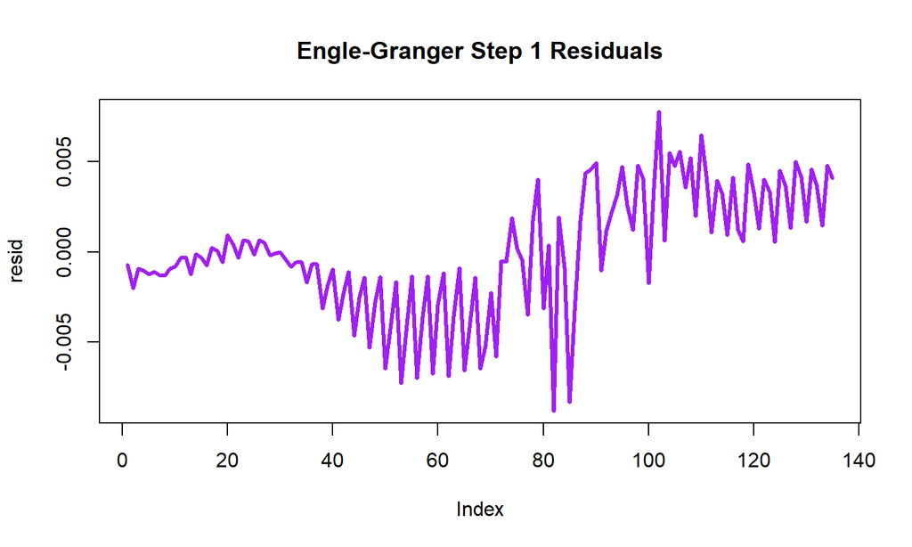

```r
resid <- fit$residuals
plot(resid, type = "l", lwd = 3, col = "purple", main = "Engle-Granger Step 1 Residuals")
```

## Engle-Granger Continued

Now let's test the residuals for the presence of a Unit root using the ur.df (Augmented Dickey-Fuller) test as above:

```r
adf.resid <- ur.df(resid, type = "drift", selectlags = "BIC")
#summary(adf.resid)
show(adf.resid)
```

```
##
## ###############################################################
## # Augmented Dickey-Fuller Test Unit Root / Cointegration Test #
## ###############################################################
##
## The value of the test statistic is: -3.6917 6.8545
```

## Engle-Granger Continued

You can see that there is fairly strong evidence of stationarity between the S&P 500 and the Futures contract! That is, at all levels of significance we reject the null hypothesis of a Unit root.

We tentatively conclude that there is a cointegrating relationship between the S&P 500 and the S&P 500 Futures contract.

The cointegrating vector is obtained as \([1, - \hat{\beta}]\) from the first-step cointegrating regression above. So in this case: \(\hat{\beta} = 0.99646\). So for all practical purposes the cointegrating vector is \([1, -1]\).

*Question:* how is this estimate related to the minimum-variance hedge obtained from the standard procedure using OLS regression?

*NB:* Step two in the Engle-Granger Procedure is to now use the residuals as a plug-in to the error-correction model. We will not do that here, and you need not do so for your midterm!